# 12_2. Multivariate Distance Using Bray-Curtis Mean to Mean

- Show All Code
- Hide All Code
- View Source

Author

Colin J Lee

We want to calculate the multivariate distance between two profiles, between and within-person. Bray-Curtis dissimilarity is an absolute distance metric, like Euclidian and Manhattan, but it can be decomposed into replacement (variables in one profile are higher *and* lower than another profile) and nestedness (one profile’s variables are uniformly higher or lower than another profile). At the between-level: we want to calculate the Bray-Curtis dissimilarity between a profile and the mean of the sample’s aggregate profiles. i think? Within p: 1. B-C between a profile’s means and the mean of the participant’s time series 2. B-C between one profile’s means and another profile’s means (obv within person)

Between person: 1. distance matrix of profile means 2. a profile’s means and sample profile mean

within-person: 1. a profile’s mean and time series mean 2. a profile’s mean and another profile’s mean

typology: 1. profile mean and typology

Data I need: Mean vector of profiles

Mean vector of sample

two row df with the person mean as a row and profile means as a row

```r
#sample mean
ipcs_sample_mean <- describe(ipcs_wide_sit %>% select(Sociability:CrtvImagination)) %>%
  select(mean)

ipcs_nested_profiles <- ipcs_nested_profiles %>%
  mutate(sample_mean = rep(ipcs_sample_mean, nrow(ipcs_nested_profiles)))

#profile means
ipcs_nested_profiles <- ipcs_nested_profiles %>%
  mutate(profile_mean = map(data, colMeans)) #profile means

#person means
ipcs_nested_pre_LPA <- ipcs_nested_pre_LPA %>%
  mutate(person_mean = map(data, colMeans))

#add person_means to nested_profile df
ipcs_nested_pre_LPA <- ipcs_nested_pre_LPA %>% select(-data)
ipcs_nested_profiles <- ipcs_nested_profiles %>% left_join(ipcs_nested_pre_LPA) %>%
  arrange(SID)
#insert person mean as first row of dataframe
ipcs_nested_profiles <- ipcs_nested_profiles %>%
  mutate(prof_to_person = map2(person_mean, profile_mean, function(x, y) bind_rows(x = x, y = y)))

#typ prep below
```

Typologies in a separate df 3 Typologies from Merz and Roesch. Taken from table 2

```r
# they are in NEOAC order; also, reverse scoring neurocitism
well_adj_vec <- c((6 - 2.38), 3.6, 3.78, 4.19, 3.72)
reserved_vec <- c((6 - 3.21), 2.65, 3.23, 3.6, 3.29)
excitable_vec <- c((6 - 3.69), 3.74, 3.84, 4.10, 3.5)

#EACNO order
index <- c(2,4,5,1,3)
well_adj_vec <- well_adj_vec[index]
reserved_vec <- reserved_vec[index]
excitable_vec <- excitable_vec[index]

#POMP
pomp <- function(x, min, max){
  (x - min)/(max - min)*100
}

reserved_vec <- pomp(x = reserved_vec, min = 1, max = 5)
names(reserved_vec) <- c("Extraversion", "Agreeableness", "Conscientiousness", "Neuroticism_r", "Openness")
well_adj_vec <- pomp(x = well_adj_vec, min = 1, max = 5)
names(well_adj_vec) <- c("Extraversion", "Agreeableness", "Conscientiousness", "Neuroticism_r", "Openness")
excitable_vec <- pomp(x = excitable_vec, min = 1 , max = 5)
names(excitable_vec) <- c("Extraversion", "Agreeableness", "Conscientiousness", "Neuroticism_r", "Openness")

# #make them lists for mapping
reserved_list <- rep(list(reserved_vec), nrow(ipcs_nested_profiles))
well_adj_list <- rep(list(well_adj_vec), nrow(ipcs_nested_profiles))
excitable_list <- rep(list(excitable_vec), nrow(ipcs_nested_profiles))
```

## now we can do person analyses

1. Between-person
2. mean profile - mean profile across sample

```r
#matrix of profile means
mc_prof_prof_dist <- mc %>%
  select(Sociability:CrtvImagination) %>% #facets only
  as.matrix

prof_prof_bray <- bray.part(mc_prof_prof_dist) #lower tri mat
prof_prof_bray_ipcs <- prof_prof_bray
save(prof_prof_bray_ipcs, file = "Data/prof_prof_bray_ipcs.RData")

#make it a df to make comparisons between repl and nest
prof_prof_btwn_bray <- data.frame(
  bray = prof_prof_bray$bray,
  repl = prof_prof_bray$bray.bal,
  nest = prof_prof_bray$bray.gra
)
#what proportion is repl>nest
table(prof_prof_btwn_bray$repl > prof_prof_btwn_bray$nest)
```

```
FALSE  TRUE
25556  8374
```

```r
8374/33930
```

```
[1] 0.2468022
```

```r
#descriptives
describe(prof_prof_bray[["bray"]])
```

|  | vars | n | mean | sd | median | trimmed | mad | min | max | range | skew | kurtosis | se |
| --- | --- | --- | --- | --- | --- | --- | --- | --- | --- | --- | --- | --- | --- |
| X1 | 1 | 33930 | 0.1269586 | 0.06556901 | 0.1114142 | 0.1188902 | 0.0564536 | 0.01518439 | 0.5368707 | 0.5216863 | 1.269379 | 2.05944 | 0.0003559645 |

```r
describe(prof_prof_bray[["bray.bal"]])
```

|  | vars | n | mean | sd | median | trimmed | mad | min | max | range | skew | kurtosis | se |
| --- | --- | --- | --- | --- | --- | --- | --- | --- | --- | --- | --- | --- | --- |
| X1 | 1 | 33930 | 0.02626746 | 0.03384622 | 0.01544787 | 0.02026727 | 0.02290301 | 0 | 0.3217146 | 0.3217146 | 2.765598 | 13.04532 | 0.0001837461 |

```r
describe(prof_prof_bray[["bray.gra"]])
```

|  | vars | n | mean | sd | median | trimmed | mad | min | max | range | skew | kurtosis | se |
| --- | --- | --- | --- | --- | --- | --- | --- | --- | --- | --- | --- | --- | --- |
| X1 | 1 | 33930 | 0.1006911 | 0.07636392 | 0.08559276 | 0.09245338 | 0.07641508 | 1.606977e-06 | 0.5368707 | 0.5368691 | 1.017694 | 1.114973 | 0.0004145685 |

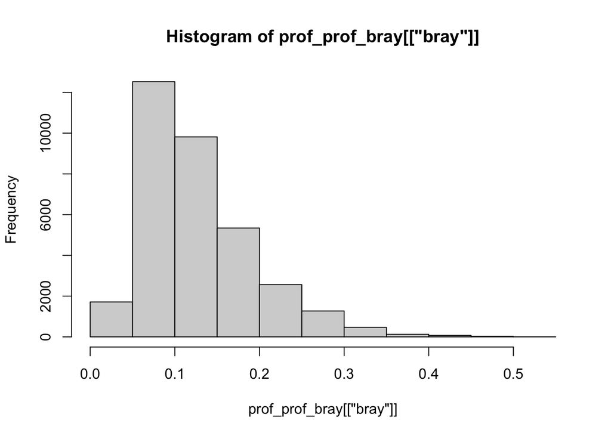

```r
hist(prof_prof_bray[["bray"]])
```

2. mean profile - sample mean

```r
#matrix of profile means and sample mean
mc_prof_sample_dist <- bind_rows(colMeans(ipcs_wide_sit %>% select(Sociability:CrtvImagination)), mc %>% select(Sociability:CrtvImagination)) %>%
  as.matrix()

prof_sample_bray <- bray.part(mc_prof_sample_dist) #lower tri mat

#so i want the first column (sample compared with each profile)
prof_sample_bray[["bray"]][1:nrow(ipcs_nested_profiles)] # the distance between the sample mean and the other 191 profiles; 1 as an index because bray.part output excludes the [1,1] position
```

```
  [1] 0.07253438 0.10365438 0.05038288 0.11815225 0.05603028 0.12607442
  [7] 0.03614396 0.03583077 0.13816880 0.05580327 0.06488012 0.07000723
 [13] 0.04489770 0.10178140 0.21770653 0.07533472 0.11641555 0.28002678
 [19] 0.03246734 0.11403774 0.07089700 0.04679945 0.10400970 0.04561193
 [25] 0.08984322 0.07161893 0.05384697 0.18295318 0.07160408 0.08210638
 [31] 0.12453729 0.08058149 0.05249367 0.37064059 0.05365814 0.13926763
 [37] 0.17993540 0.14163503 0.04173499 0.06635025 0.15316045 0.02941781
 [43] 0.10947490 0.04022632 0.12473018 0.10761001 0.03795260 0.06141721
 [49] 0.02389301 0.06979015 0.15775703 0.02732515 0.06558896 0.07818285
 [55] 0.04295984 0.10629987 0.04362976 0.06988059 0.08432060 0.07948805
 [61] 0.08092706 0.12451572 0.08349897 0.08784754 0.11205519 0.08789409
 [67] 0.09774290 0.04297107 0.03696426 0.08374214 0.08534280 0.06690618
 [73] 0.13022987 0.06203115 0.06192268 0.13360493 0.04714958 0.08412809
 [79] 0.05286279 0.11385115 0.07142847 0.05829594 0.04771070 0.08442208
 [85] 0.04587236 0.12848253 0.07060640 0.04587981 0.09776028 0.09528782
```

[output cut: 29 more lines]

```r
#make it a df to make comparisons between repl and nest
prof_sample_btwn_bray <- data.frame(
  bray = prof_sample_bray[["bray"]][1:nrow(ipcs_nested_profiles)],
  repl = prof_sample_bray[["bray.bal"]][1:nrow(ipcs_nested_profiles)],
  nest = prof_sample_bray[["bray.gra"]][1:nrow(ipcs_nested_profiles)]
)
#what proportion is repl>nest
table(prof_sample_btwn_bray$repl > prof_sample_btwn_bray$nest)
```

```
FALSE  TRUE
  205    56
```

```r
56/261
```

```
[1] 0.2145594
```

```r
describe(prof_sample_bray[["bray"]][1:nrow(ipcs_nested_profiles)])
```

|  | vars | n | mean | sd | median | trimmed | mad | min | max | range | skew | kurtosis | se |
| --- | --- | --- | --- | --- | --- | --- | --- | --- | --- | --- | --- | --- | --- |
| X1 | 1 | 261 | 0.08909556 | 0.04816978 | 0.07948805 | 0.08267188 | 0.04135305 | 0.02389301 | 0.3706406 | 0.3467476 | 1.731498 | 5.130029 | 0.002981635 |

```r
describe(prof_sample_bray[["bray.bal"]][1:nrow(ipcs_nested_profiles)])
```

|  | vars | n | mean | sd | median | trimmed | mad | min | max | range | skew | kurtosis | se |
| --- | --- | --- | --- | --- | --- | --- | --- | --- | --- | --- | --- | --- | --- |
| X1 | 1 | 261 | 0.01591554 | 0.02388508 | 0.008138931 | 0.01201957 | 0.01206678 | 0 | 0.275837 | 0.275837 | 5.466261 | 52.33017 | 0.001478449 |

```r
describe(prof_sample_bray[["bray.gra"]][1:nrow(ipcs_nested_profiles)])
```

|  | vars | n | mean | sd | median | trimmed | mad | min | max | range | skew | kurtosis | se |
| --- | --- | --- | --- | --- | --- | --- | --- | --- | --- | --- | --- | --- | --- |
| X1 | 1 | 261 | 0.07318002 | 0.05344511 | 0.06564757 | 0.06724897 | 0.0527543 | 0.001170702 | 0.3706406 | 0.3694699 | 1.291159 | 3.184539 | 0.003308169 |

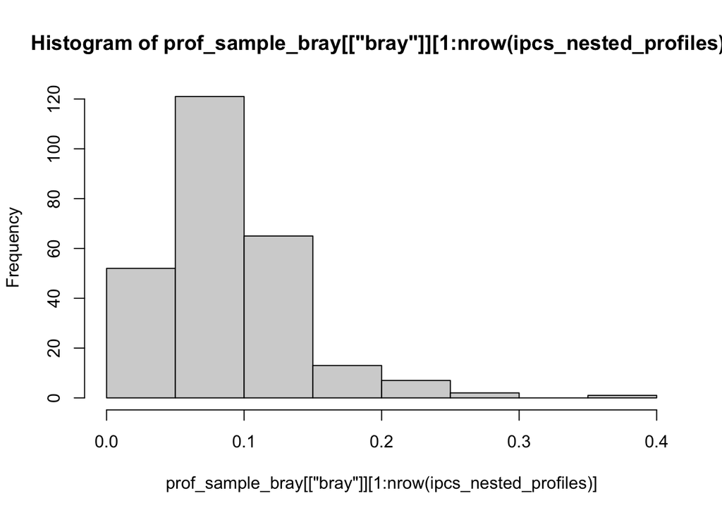

```r
hist(prof_sample_bray[["bray"]][1:nrow(ipcs_nested_profiles)])
```

```r
prof_sample_dist_ipcs <- prof_sample_bray[["bray"]][1:nrow(ipcs_nested_profiles)] %>% as.data.frame
colnames(prof_sample_dist_ipcs) <- "dist"
save(prof_sample_dist_ipcs, file = "Data/prof_sample_dist_ipcs.RData")

which.min(prof_sample_bray[["bray"]][1:nrow(ipcs_nested_profiles)])
```

```
[1] 49
```

```r
mc$distances <- prof_sample_bray[["bray"]][1:nrow(ipcs_nested_profiles)]

minmaxmc <- mc %>% select(SID, Profiles, distances)
```

plot least and most similar

```r
#pp sample mean to plot
ipcs_sample_mean_plot <- describe(ipcs_wide_sit %>% select(Sociability:CrtvImagination)) %>%
  select(mean)
ipcs_sample_mean_plot$facet <- rownames(ipcs_sample_mean_plot)
ipcs_sample_mean_plot$facet <- factor(ipcs_sample_mean_plot$facet, levels = c("Sociability", "EnergyLevel", "Assertive", "Trust", "Respect", "Compassion", "Productivity", "Responsibility", "Organization", "Depression_r", "Anxiety_r", "EmotionalVol_r", "IntCuriosity", "AesthSense", "CrtvImagination"))
ipcs_sample_mean_plot <- ipcs_sample_mean_plot %>% rename(value = mean) %>% mutate(Profiles = "Sample Mean")

#max dist; look at minmaxmc

prof_to_sample_max <- mc %>% filter(SID == 25 & Profiles == 2) %>%
  select(Sociability:CrtvImagination) %>%
  t() %>%
  as.data.frame()

prof_to_sample_max$facet <- rownames(prof_to_sample_max)
prof_to_sample_max$facet <- factor(prof_to_sample_max$facet, levels = c("Sociability", "EnergyLevel", "Assertive", "Trust", "Respect", "Compassion", "Productivity", "Responsibility", "Organization", "Depression_r", "Anxiety_r", "EmotionalVol_r", "IntCuriosity", "AesthSense", "CrtvImagination"))
prof_to_sample_max <- prof_to_sample_max %>% rename(value = V1) %>% mutate(Profiles = paste0("Max Distance (0.37)" ))
prof_to_sample_max <- bind_rows(prof_to_sample_max, ipcs_sample_mean_plot)

#min
prof_to_sample_min <- mc %>% filter(SID == 34 & Profiles == 1) %>%
  select(Sociability:CrtvImagination) %>%
  t() %>%
  as.data.frame()

prof_to_sample_min$facet <- rownames(prof_to_sample_min)
prof_to_sample_min$facet <- factor(prof_to_sample_min$facet, levels = c("Sociability", "EnergyLevel", "Assertive", "Trust", "Respect", "Compassion", "Productivity", "Responsibility", "Organization", "Depression_r", "Anxiety_r", "EmotionalVol_r", "IntCuriosity", "AesthSense", "CrtvImagination"))
prof_to_sample_max_min <- bind_rows(prof_to_sample_max, prof_to_sample_min %>% rename(value = V1) %>% mutate(Profiles = paste0("Min Distance (0.02)")))

profile_plot_fnc <- function(df){
  df %>%
    ggplot(aes(x = facet, y = value, group = Profiles, color = Profiles)) +
    geom_line(linewidth = 1.25) +
    geom_point(size = 2.25, color = "black") +
    labs(x = NULL, y = "Self-Reported Score (POMP)") +
    ylim(0,103) +
    theme_bw(base_size = 8) +
    theme(axis.text.x = element_text(angle = 45, hjust = 1, size = 10), legend.position = "top") +
    labs(title = "Profiles With Maximum and Minimum Distances from IPCS Facet Means") +
    #annotate("rect", xmin = 3.8, xmax = 6.2, ymin = 46, ymax = 93, fill = "green", alpha = .2) +
    #annotate("rect", xmin = 0.8, xmax = 3.2, ymin = 25, ymax = 77, fill = "red", alpha = .2) +
    geom_vline(xintercept = c(3.5, 6.5, 9.5, 12.5), size = 0.25, alpha = 0.8) +
    annotate("text", x = 2, y = 102, size = 2.5,label = "Extraversion") +
    annotate("text", x = 5, y = 102, size = 2.5,label = "Agreeableness") +
    annotate("text", x = 8, y = 102, size=  2.5, label = "Conscientiousness") +
    annotate("text", x = 11, y = 102, size = 2.5, label = "Emotional Stability") +
    annotate("text", x = 14, y = 102, size = 2.5, label = "Openness")
}

pdf(file = "z.Plots/Profile Comparisons/Min Max BCD Plot.pdf")
profile_plot_fnc(prof_to_sample_max_min)
dev.off()
```

```r
max_min_dist_plot <- prof_to_sample_max_min
save(max_min_dist_plot, file = "Data/max_min_dist_plot.RData")
```

2. within
1. profile mean-person mean

```r
ipcs_nested_profiles_multi <- ipcs_nested_profiles %>%
  group_by(SID) %>%
  filter(length(unique(Profiles)) > 1) %>% #>1 profile only for within person analyses
  ungroup() %>%
  mutate(prof_person_dist = map(prof_to_person, function(x) bray.part(x))) #1 BCD value, decomposed into replacement and nestedness

profobs_to_personmean <- list()
#so fucking stupid i had to for loop but map was killing me
for(i in 1:nrow(ipcs_nested_profiles_multi)){
    profobs_to_personmean[[i]] <- ipcs_nested_profiles_multi$prof_person_dist[[i]]$bray #first col
}

fuck <- map_dfr(profobs_to_personmean, describe)
obs_to_person_mean <- cbind(ipcs_nested_profiles_multi$SID, ipcs_nested_profiles_multi$Profiles, fuck) %>%
  rename(SID = "ipcs_nested_profiles_multi$SID",
         Profiles = "ipcs_nested_profiles_multi$Profiles") %>%
  select(SID, Profiles, mean, median, min, max, se)

mean(obs_to_person_mean$mean) #0.17
```

```
[1] 0.07446996
```

```r
sd(obs_to_person_mean$mean) #.04
```

```
[1] 0.03953819
```

```r
min(obs_to_person_mean$min) #.01
```

```
[1] 0.006615167
```

```r
max(obs_to_person_mean$max) #.30
```

```
[1] 0.2962618
```

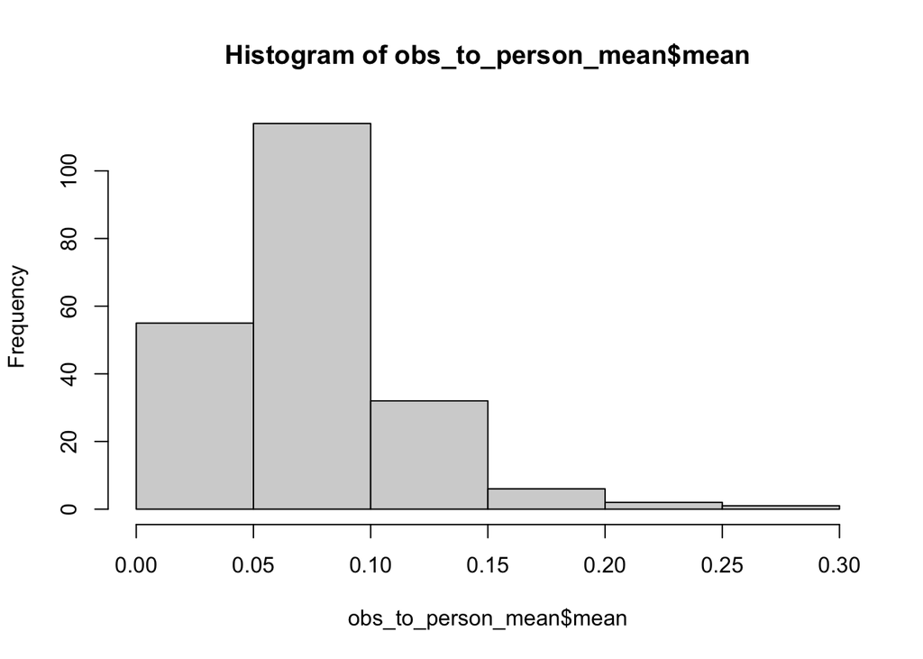

```r
hist(obs_to_person_mean$mean)
```

```r
obs_to_person_mean_ipcs <- obs_to_person_mean
save(obs_to_person_mean_ipcs, file = "Data/obs_to_person_mean_ipcs.RData")

#y <- obs_to_person_mean %>% filter(SID == 214)
```

2. within profile-profile

```r
#multi profile only
ipcs_nested_profiles_multi <- ipcs_nested_profiles %>%
  group_by(SID) %>%
  filter(length(unique(Profiles)) > 1) %>%
  ungroup() %>%
  select(SID, Profiles, profile_mean) %>% arrange(SID)

#so essentially, just bind rows the profile means within person and then bray curt that shit
ipcs_nested_profiles_multi <- ipcs_nested_profiles_multi %>%
  select(-Profiles) %>%
  group_by(SID) %>%
  summarize_all(~ list(c_across(profile_mean))) %>%
  mutate(profile_mean = map(profile_mean, unlist),
         profile_mean_df = map(profile_mean, function(x) matrix(x, byrow = TRUE, ncol = 15))) %>%
  ungroup() %>%
  select(SID, profile_mean_df)


#now bray curtis grouping by SID
ipcs_nested_profiles_multi <- ipcs_nested_profiles_multi %>%
  mutate(prof_to_prof = map(profile_mean_df, bray.part))

prof_prof <- map(ipcs_nested_profiles_multi$prof_to_prof, unlist) %>% unlist()
351/3
```

```
[1] 117
```

```r
head(prof_prof)
```

```
  bray.bal   bray.gra       bray   bray.bal   bray.gra       bray
0.00000000 0.16475885 0.16475885 0.04185233 0.08004583 0.12189817
```

```r
#organize into a df with three columns
prof_prof_df <- matrix(prof_prof, ncol = 3, byrow = TRUE) %>%
  as.data.frame() %>%
  rename(replacement = V1,
         nestedness = V2,
         bray = V3)

describe(prof_prof_df$replacement)
```

|  | vars | n | mean | sd | median | trimmed | mad | min | max | range | skew | kurtosis | se |
| --- | --- | --- | --- | --- | --- | --- | --- | --- | --- | --- | --- | --- | --- |
| X1 | 1 | 117 | 0.01877189 | 0.04162938 | 0 | 0.007786374 | 0 | 0 | 0.2041684 | 0.2041684 | 2.893826 | 8.046551 | 0.003848637 |

```r
describe(prof_prof_df$nestedness)
```

|  | vars | n | mean | sd | median | trimmed | mad | min | max | range | skew | kurtosis | se |
| --- | --- | --- | --- | --- | --- | --- | --- | --- | --- | --- | --- | --- | --- |
| X1 | 1 | 117 | 0.1317327 | 0.05787871 | 0.1326333 | 0.1329537 | 0.04172762 | 0 | 0.3412962 | 0.3412962 | 0.03002124 | 1.427161 | 0.005350888 |

```r
describe(prof_prof_df$bray)
```

|  | vars | n | mean | sd | median | trimmed | mad | min | max | range | skew | kurtosis | se |
| --- | --- | --- | --- | --- | --- | --- | --- | --- | --- | --- | --- | --- | --- |
| X1 | 1 | 117 | 0.1421706 | 0.05966387 | 0.1374375 | 0.141694 | 0.042207 | 0 | 0.3412962 | 0.3412962 | 0.2092503 | 1.544592 | 0.005515927 |

```r
prof_prof_within_dist <- prof_prof_df %>% select(bray)
save(prof_prof_within_dist, file ="Data/prof_prof_within_dist.RData")
```

Typology

```r
#aggregate into traits for typology comps
trait_fun <- function(df){
  df %>%
    rowwise() %>%
    mutate(Extraversion = mean(c_across(Sociability:Assertive)),
           Agreeableness = mean(c_across(Trust:Compassion)),
           Conscientiousness = mean(c_across(Productivity:Organization)),
           Neuroticism_r = mean(c_across(Depression_r:EmotionalVol_r)),
           Openness = mean(c_across(IntCuriosity:CrtvImagination))
           ) %>%
    ungroup() %>%
    select(Extraversion:Openness)
}

ipcs_nested_traits <- ipcs_nested_profiles %>%
  mutate(trait_df = map(data, trait_fun),
         trait_mean = map(trait_df, colMeans),
         trait_mean = map(trait_mean, as.data.frame),
         trait_mean = map(trait_mean, t)) %>%
  select(SID, Profiles, trait_mean, trait_df) %>%
  mutate(trait_variance = map(trait_df, function(x) apply(x, 2, sd)))

#combine trait and typology vector and compute bray
ipcs_nested_traits_bcd <- ipcs_nested_traits %>%
  mutate(reserved_df = map2(reserved_list,
                            as.vector(ipcs_nested_traits$trait_mean),
                            function(x,y) rbind(x,y)),
         excitable_df = map2(excitable_list,
                            as.vector(ipcs_nested_traits$trait_mean),
                            function(x,y) rbind(x,y)),
         well_adj_df = map2(well_adj_list,
                            as.vector(ipcs_nested_traits$trait_mean),
                            function(x,y) rbind(x,y))) %>%
  mutate(res_dist = map(reserved_df, bray.part), #distance matrix
         well_dist = map(well_adj_df, bray.part),
         exc_dist = map(excitable_df, bray.part))
save(ipcs_nested_traits_bcd, file = "Data/ipcs_nested_traits_bcd.RData")
#extract estimates
typology_sample <- ipcs_nested_traits_bcd

#extract first column
reserved_distance_vector <- list()
#so fucking stupid i had to for loop but map was killing me
for(i in 1:nrow(typology_sample)){
    reserved_distance_vector[[i]] <- typology_sample$res_dist[[i]]$bray #first col
}

reserved_distance_df <- map_dfr(reserved_distance_vector, describe)
reserved_distance_df <- cbind(typology_sample$SID, typology_sample$Profiles, reserved_distance_df) %>%
  rename(SID = "typology_sample$SID",
         Profiles = "typology_sample$Profiles") %>%
  select(SID, Profiles, mean, sd, median, min, max, se)

reserved_distance_df$typology <- "Reserved"

mean(reserved_distance_df$mean) #0.09
```

```
[1] 0.1088753
```

```r
min(reserved_distance_df$min) #.03
```

```
[1] 0.02037426
```

```r
max(reserved_distance_df$max) #.28
```

```
[1] 0.3055692
```

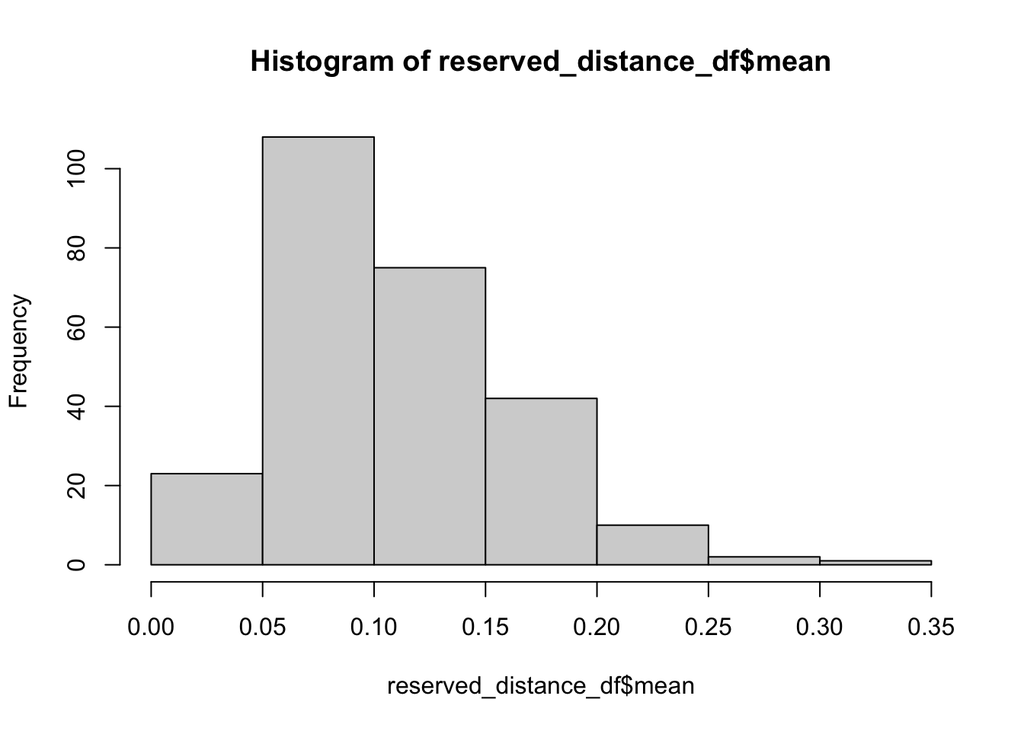

```r
hist(reserved_distance_df$mean)
```

```r
well_adj_distance_vector <- list()
#so fucking stupid i had to for loop but map was killing me
for(i in 1:nrow(typology_sample)){
    well_adj_distance_vector[[i]] <- typology_sample$well_dist[[i]]$bray #first col
}

well_adj_distance_df <- map_dfr(well_adj_distance_vector, describe)
well_adj_distance_df <- cbind(typology_sample$SID, typology_sample$Profiles, well_adj_distance_df) %>%
  rename(SID = "typology_sample$SID",
         Profiles = "typology_sample$Profiles") %>%
  select(SID, Profiles, mean, sd, median, min, max, se)

well_adj_distance_df$typology <- "Well-Adjusted"


mean(well_adj_distance_df$mean) #0.13
```

```
[1] 0.1014152
```

```r
min(well_adj_distance_df$min) #.03
```

```
[1] 0.01853597
```

```r
max(well_adj_distance_df$max) #.37
```

```
[1] 0.4247048
```

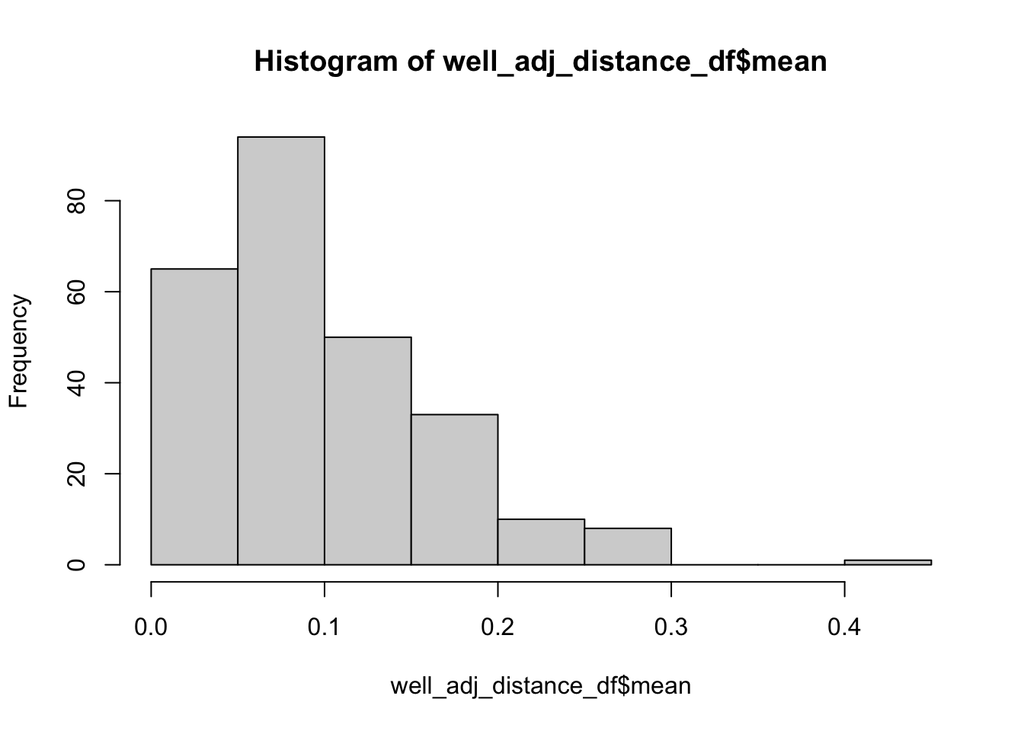

```r
hist(well_adj_distance_df$mean)
```

```r
excitable_distance_vector <- list()
#so fucking stupid i had to for loop but map was killing me
for(i in 1:nrow(typology_sample)){
    excitable_distance_vector[[i]] <- typology_sample$exc_dist[[i]]$bray #first col
}

excitable_distance_df <- map_dfr(excitable_distance_vector, describe)
excitable_distance_df <- cbind(typology_sample$SID, typology_sample$Profiles, excitable_distance_df) %>%
  rename(SID = "typology_sample$SID",
         Profiles = "typology_sample$Profiles") %>%
  select(SID, Profiles, mean, sd, median, min, max, se)

excitable_distance_df$typology <- "Excitable"

mean(excitable_distance_df$mean) #0.15
```

```
[1] 0.1361625
```

```r
min(excitable_distance_df$min) #.07
```

```
[1] 0.04171945
```

```r
max(excitable_distance_df$max) #.33
```

```
[1] 0.3795882
```

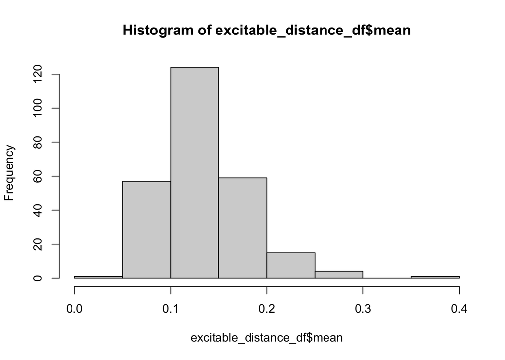

```r
hist(excitable_distance_df$mean)
```

```r
bray_typ <- bind_rows(excitable_distance_df, reserved_distance_df, well_adj_distance_df)
save(bray_typ, file = "Data/bray_typ.RData")

#overall bray
typology_bray_summary <- bray_typ %>%
  group_by(typology) %>%
  summarize(mean_distance = mean(mean, na.rm = TRUE),
            sd_distance = sd(mean, na.rm = TRUE))
typology_bray_summary
```

| typology | mean_distance | sd_distance |
| --- | --- | --- |
| Excitable | 0.1361625 | 0.04422894 |
| Reserved | 0.1088753 | 0.05123099 |
| Well-Adjusted | 0.1014152 | 0.06437987 |

Replacement

```r
#extract first column
reserved_distance_vector <- list()
#so fucking stupid i had to for loop but map was killing me
for(i in 1:nrow(typology_sample)){
    reserved_distance_vector[[i]] <- typology_sample$res_dist[[i]]$bray.bal
}

reserved_distance_df <- map_dfr(reserved_distance_vector, describe)
reserved_distance_df <- cbind(typology_sample$SID, typology_sample$Profiles, reserved_distance_df) %>%
  rename(SID = "typology_sample$SID",
         Profiles = "typology_sample$Profiles") %>%
  select(SID, Profiles, mean, sd, median, min, max, se)

reserved_distance_df$typology <- "Reserved"

mean(reserved_distance_df$mean)
```

```
[1] 0.01737416
```

```r
min(reserved_distance_df$min)
```

```
[1] 0
```

```r
max(reserved_distance_df$max)
```

```
[1] 0.1008192
```

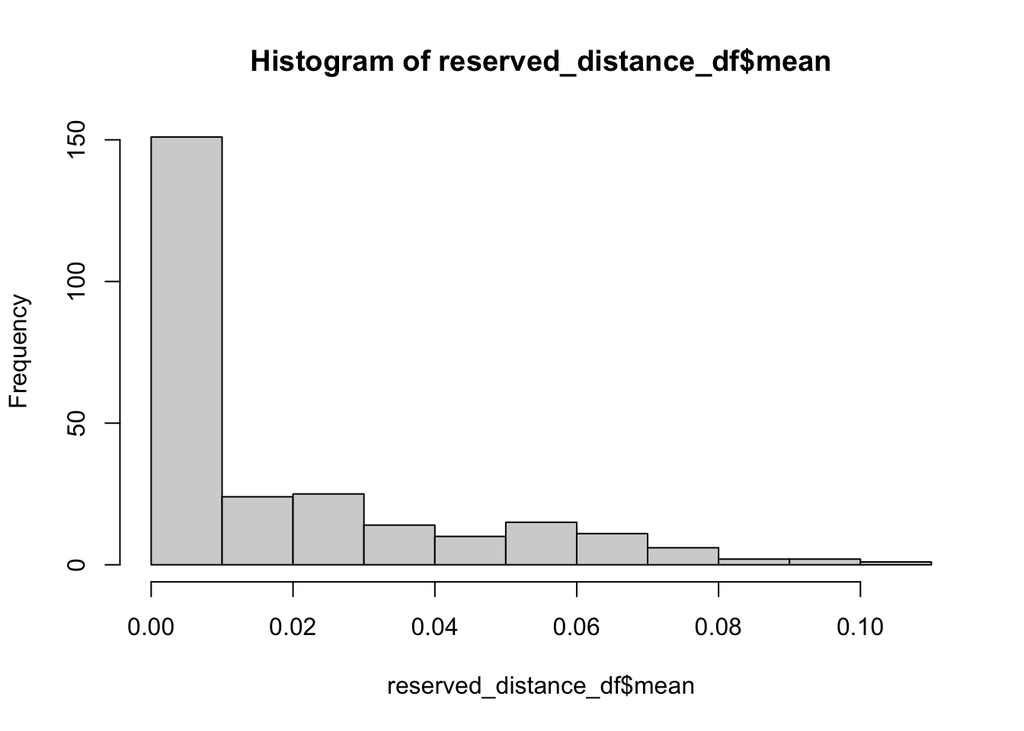

```r
hist(reserved_distance_df$mean)
```

```r
well_adj_distance_vector <- list()
#so fucking stupid i had to for loop but map was killing me
for(i in 1:nrow(typology_sample)){
    well_adj_distance_vector[[i]] <- typology_sample$well_dist[[i]]$bray.bal
}

well_adj_distance_df <- map_dfr(well_adj_distance_vector, describe)
well_adj_distance_df <- cbind(typology_sample$SID, typology_sample$Profiles, well_adj_distance_df) %>%
  rename(SID = "typology_sample$SID",
         Profiles = "typology_sample$Profiles") %>%
  select(SID, Profiles, mean, sd, median, min, max, se)

well_adj_distance_df$typology <- "Well-Adjusted"


mean(well_adj_distance_df$mean)
```

```
[1] 0.01041607
```

```r
min(well_adj_distance_df$min)
```

```
[1] 0
```

```r
max(well_adj_distance_df$max)
```

```
[1] 0.09483564
```

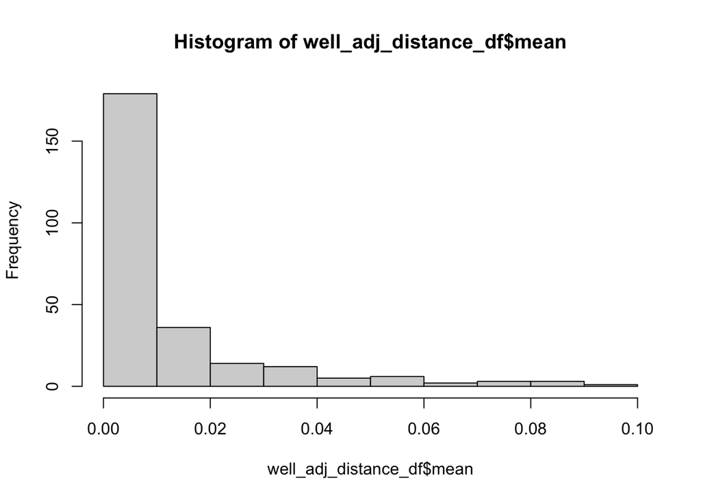

```r
hist(well_adj_distance_df$mean)
```

```r
excitable_distance_vector <- list()
#so fucking stupid i had to for loop but map was killing me
for(i in 1:nrow(typology_sample)){
    excitable_distance_vector[[i]] <- typology_sample$exc_dist[[i]]$bray.bal
}

excitable_distance_df <- map_dfr(excitable_distance_vector, describe)
excitable_distance_df <- cbind(typology_sample$SID, typology_sample$Profiles, excitable_distance_df) %>%
  rename(SID = "typology_sample$SID",
         Profiles = "typology_sample$Profiles") %>%
  select(SID, Profiles, mean, sd, median, min, max, se)

excitable_distance_df$typology <- "Excitable"

mean(excitable_distance_df$mean)
```

```
[1] 0.06454375
```

```r
min(excitable_distance_df$min)
```

```
[1] 0
```

```r
max(excitable_distance_df$max)
```

```
[1] 0.1487187
```

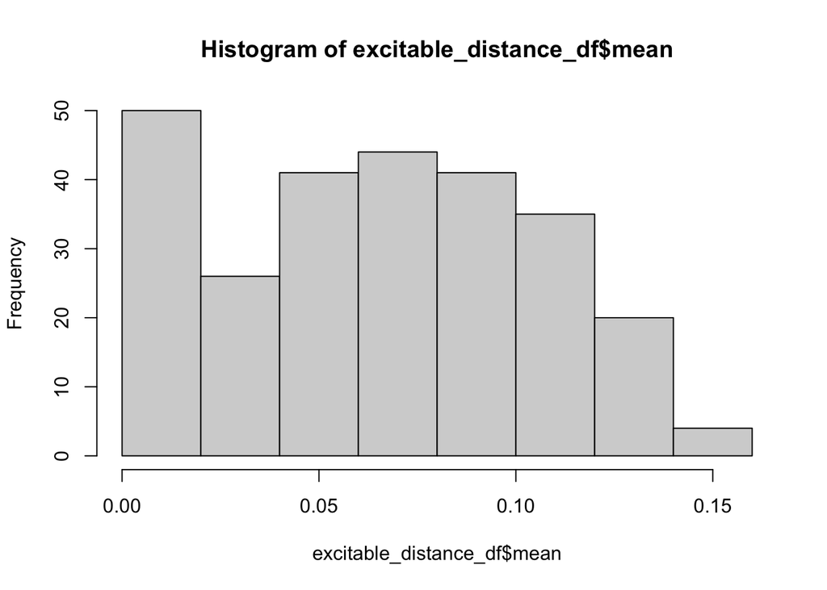

```r
hist(excitable_distance_df$mean)
```

```r
bray_typ <- bind_rows(excitable_distance_df, reserved_distance_df, well_adj_distance_df)

#overall bray
typology_repl_summary <- bray_typ %>%
  group_by(typology) %>%
  summarize(mean_repl = mean(mean, na.rm = TRUE),
            sd_repl = sd(mean, na.rm = TRUE))
```

Nestedness

```r
#extract first column
reserved_distance_vector <- list()
#so fucking stupid i had to for loop but map was killing me
for(i in 1:nrow(typology_sample)){
    reserved_distance_vector[[i]] <- typology_sample$res_dist[[i]]$bray.gra
}

reserved_distance_df <- map_dfr(reserved_distance_vector, describe)
reserved_distance_df <- cbind(typology_sample$SID, typology_sample$Profiles, reserved_distance_df) %>%
  rename(SID = "typology_sample$SID",
         Profiles = "typology_sample$Profiles") %>%
  select(SID, Profiles, mean, sd, median, min, max, se)

reserved_distance_df$typology <- "Reserved"

mean(reserved_distance_df$mean)
```

```
[1] 0.09150116
```

```r
min(reserved_distance_df$min) #
```

```
[1] 0.001359894
```

```r
max(reserved_distance_df$max) #
```

```
[1] 0.3055692
```

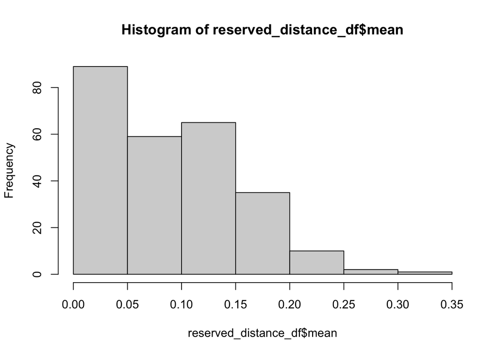

```r
hist(reserved_distance_df$mean)
```

```r
well_adj_distance_vector <- list()
#so fucking stupid i had to for loop but map was killing me
for(i in 1:nrow(typology_sample)){
    well_adj_distance_vector[[i]] <- typology_sample$well_dist[[i]]$bray.gra
}

well_adj_distance_df <- map_dfr(well_adj_distance_vector, describe)
well_adj_distance_df <- cbind(typology_sample$SID, typology_sample$Profiles, well_adj_distance_df) %>%
  rename(SID = "typology_sample$SID",
         Profiles = "typology_sample$Profiles") %>%
  select(SID, Profiles, mean, sd, median, min, max, se)

well_adj_distance_df$typology <- "Well-Adjusted"


mean(well_adj_distance_df$mean)
```

```
[1] 0.09099908
```

```r
min(well_adj_distance_df$min) #.
```

```
[1] 0.0003558537
```

```r
max(well_adj_distance_df$max) #.
```

```
[1] 0.4247048
```

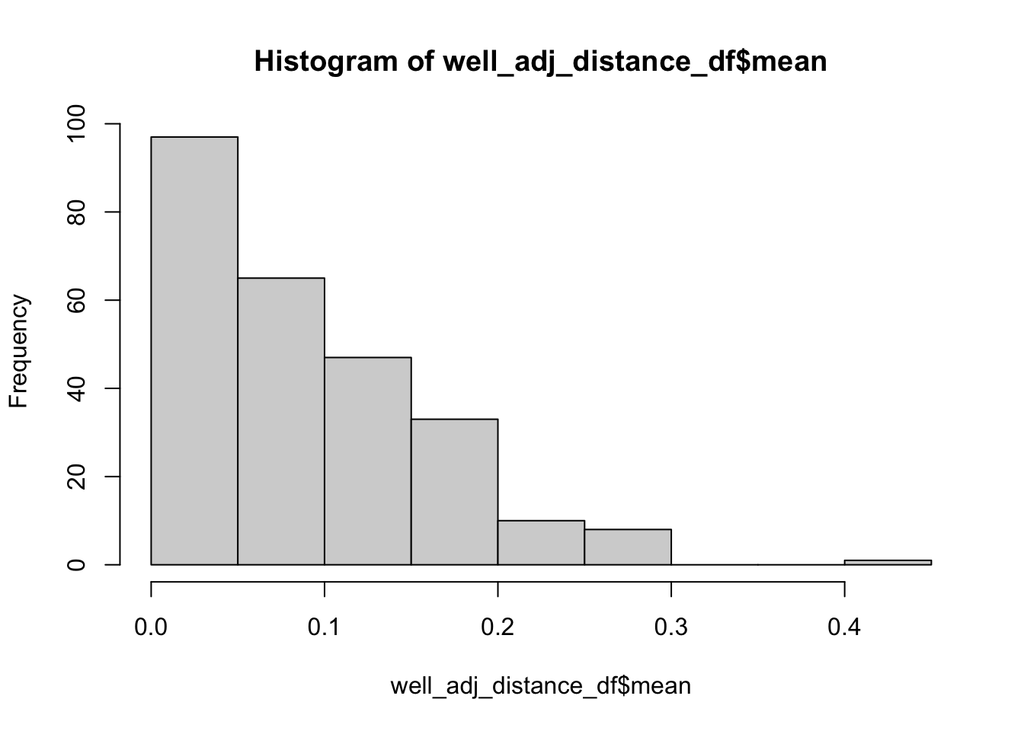

```r
hist(well_adj_distance_df$mean)
```

```r
excitable_distance_vector <- list()
#so fucking stupid i had to for loop but map was killing me
for(i in 1:nrow(typology_sample)){
    excitable_distance_vector[[i]] <- typology_sample$exc_dist[[i]]$bray.gra
}

excitable_distance_df <- map_dfr(excitable_distance_vector, describe)
excitable_distance_df <- cbind(typology_sample$SID, typology_sample$Profiles, excitable_distance_df) %>%
  rename(SID = "typology_sample$SID",
         Profiles = "typology_sample$Profiles") %>%
  select(SID, Profiles, mean, sd, median, min, max, se)

excitable_distance_df$typology <- "Excitable"

mean(excitable_distance_df$mean)
```

```
[1] 0.07161876
```

```r
min(excitable_distance_df$min)
```

```
[1] 9.091327e-05
```

```r
max(excitable_distance_df$max)
```

```
[1] 0.3795882
```

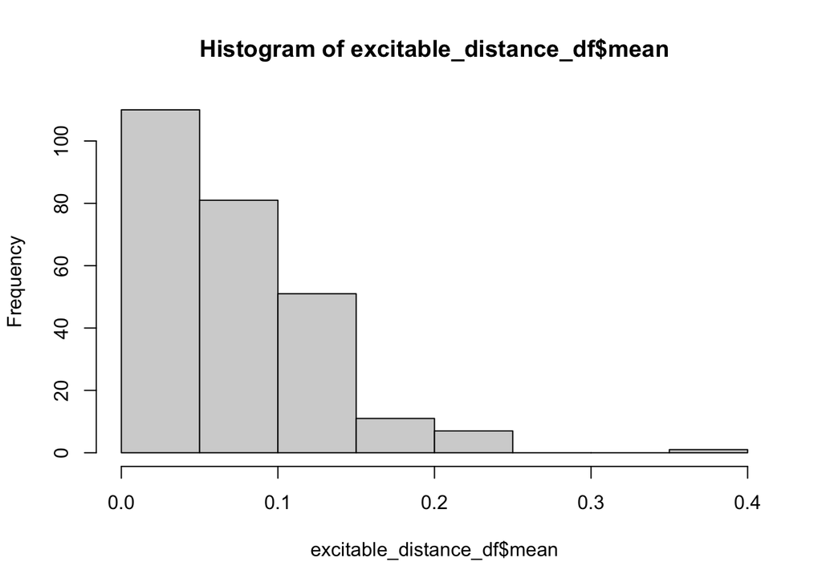

```r
hist(excitable_distance_df$mean)
```

```r
bray_typ <- bind_rows(excitable_distance_df, reserved_distance_df, well_adj_distance_df)

#overall bray
typology_nest_summary <- bray_typ %>%
  group_by(typology) %>%
  summarize(mean_nest = mean(mean, na.rm = TRUE),
            sd_nest = sd(mean, na.rm = TRUE))
```

```r
fuck <- left_join(typology_bray_summary, typology_repl_summary)
fuck <- left_join(fuck, typology_nest_summary)
ipcs_typology_dist <- fuck

save(ipcs_typology_dist, file = "Data/ipcs_typology_dist.RData") #used in pps script 12 to create a table with both samples
```

Exemplar BCD analyses 1. Typology

```r
prof_to_sample_ex1 <- mc %>% filter(SID == 106 ) %>%
  select(Sociability:CrtvImagination) %>%
  t() %>%
  as.data.frame()
prof_to_sample_ex2 <- mc %>% filter(SID == 214 ) %>%
  select(Sociability:CrtvImagination) %>%
  t() %>%
  as.data.frame()

#stack
prof_to_sample_ex1 <- rbind(c(prof_to_sample_ex1$V1, prof_to_sample_ex1$V2)) %>% t %>%
  as.data.frame()

prof_to_sample_ex1$facet <- factor(c("Sociability", "EnergyLevel", "Assertive", "Trust", "Respect", "Compassion", "Productivity", "Responsibility", "Organization", "Depression_r", "Anxiety_r", "EmotionalVol_r", "IntCuriosity", "AesthSense", "CrtvImagination"), levels = (c("Sociability", "EnergyLevel", "Assertive", "Trust", "Respect", "Compassion", "Productivity", "Responsibility", "Organization", "Depression_r", "Anxiety_r", "EmotionalVol_r", "IntCuriosity", "AesthSense", "CrtvImagination")))

prof_to_sample_ex2 <- rbind(c(prof_to_sample_ex2$V1, prof_to_sample_ex2$V2, prof_to_sample_ex2$V3)) %>% t %>%
  as.data.frame()

prof_to_sample_ex2$facet <- factor(c("Sociability", "EnergyLevel", "Assertive", "Trust", "Respect", "Compassion", "Productivity", "Responsibility", "Organization", "Depression_r", "Anxiety_r", "EmotionalVol_r", "IntCuriosity", "AesthSense", "CrtvImagination"), levels = c("Sociability", "EnergyLevel", "Assertive", "Trust", "Respect", "Compassion", "Productivity", "Responsibility", "Organization", "Depression_r", "Anxiety_r", "EmotionalVol_r", "IntCuriosity", "AesthSense", "CrtvImagination"))

prof_to_sample_ex1 <- prof_to_sample_ex1 %>%
  rename(value = V1) %>%
  mutate(Profiles = c(rep("Profile 1", 15), rep("Profile 2", 15)))

prof_to_sample_ex2 <- prof_to_sample_ex2 %>%
  rename(value = V1) %>%
  mutate(Profiles = c(rep("Profile 1", 15), rep("Profile 2", 15), rep("Profile 3", 15)))


prof_to_sample_ex1 <- bind_rows(ipcs_sample_mean_plot, prof_to_sample_ex1)
prof_to_sample_ex2 <- bind_rows(ipcs_sample_mean_plot, prof_to_sample_ex2)


prof_to_sample_ex1_plot <- prof_to_sample_ex1 %>%
    ggplot(aes(x = facet, y = value, group = Profiles, color = Profiles)) +
    geom_line(linewidth = 1.25) +
    geom_point(size = 2.25, color = "black") +
    labs(x = NULL, y = "Self-Rerported Score (POMP)") +
    ylim(0,103) +
    theme_bw(base_size = 8) +
    theme(axis.text.x = element_text(angle = 45, hjust = 1, size = 10), legend.position = "top") +
    labs(title = "Exemplar 106 Profiles and IPCS Sample Mean") +
    #annotate("rect", xmin = 3.8, xmax = 6.2, ymin = 46, ymax = 93, fill = "green", alpha = .2) +
    #annotate("rect", xmin = 0.8, xmax = 3.2, ymin = 25, ymax = 77, fill = "red", alpha = .2) +
    geom_vline(xintercept = c(3.5, 6.5, 9.5, 12.5), size = 0.25, alpha = 0.8) +
    annotate("text", x = 2, y = 102, size = 2.5,label = "Extraversion") +
    annotate("text", x = 5, y = 102, size = 2.5,label = "Agreeableness") +
    annotate("text", x = 8, y = 102, size=  2.5, label = "Conscientiousness") +
    annotate("text", x = 11, y = 102, size = 2.5, label = "Emotional Stability") +
    annotate("text", x = 14, y = 102, size = 2.5, label = "Openness")



prof_to_sample_ex2_plot <- prof_to_sample_ex2 %>%
    ggplot(aes(x = facet, y = value, group = Profiles, color = Profiles)) +
    geom_line(linewidth = 1.25) +
    geom_point(size = 2.25, color = "black") +
    labs(x = NULL, y = "Self-Rerported Score (POMP)") +
    ylim(0,103) +
    theme_bw(base_size = 8) +
    theme(axis.text.x = element_text(angle = 45, hjust = 1, size = 10), legend.position = "top") +
    labs(title = "Exemplar 214 Profiles and IPCS Sample Mean") +
    #annotate("rect", xmin = 3.8, xmax = 6.2, ymin = 46, ymax = 93, fill = "green", alpha = .2) +
    #annotate("rect", xmin = 0.8, xmax = 3.2, ymin = 25, ymax = 77, fill = "red", alpha = .2) +
    geom_vline(xintercept = c(3.5, 6.5, 9.5, 12.5), size = 0.25, alpha = 0.8) +
    annotate("text", x = 2, y = 102, size = 2.5,label = "Extraversion") +
    annotate("text", x = 5, y = 102, size = 2.5,label = "Agreeableness") +
    annotate("text", x = 8, y = 102, size=  2.5, label = "Conscientiousness") +
    annotate("text", x = 11, y = 102, size = 2.5, label = "Emotional Stability") +
    annotate("text", x = 14, y = 102, size = 2.5, label = "Openness")


pdf(file = "z.Plots/Profile Comparisons/Exemplar 104 Profiles and Sample Mean.pdf")
prof_to_sample_ex1_plot
dev.off()
```

```r
pdf(file = "z.Plots/Profile Comparisons/Exemplar 214 Profiles and Sample Mean.pdf")
prof_to_sample_ex2_plot
dev.off()
```

2. Between

   exemplar profile - sample mean

```r
prof_sample_ex <- prof_sample_bray[["bray"]][1:nrow(ipcs_nested_profiles)]

#106
index_106_1 <- 123
index_106_2 <- 124

prof_sample_ex[123]
```

```
[1] 0.042117
```

```r
prof_sample_ex[124]
```

```
[1] 0.1376463
```

```r
#214
index_214_1 <- 248
index_214_2 <- 249
index_214_3 <- 250

prof_sample_ex[index_214_1]
```

```
[1] 0.1224054
```

```r
prof_sample_ex[index_214_2]
```

```
[1] 0.08900734
```

```r
prof_sample_ex[index_214_3]
```

```
[1] 0.196063
```

2. exemplar profile - all other profiles in sample

```r
prof_prof_ex <- prof_prof_bray[["bray"]] %>% as.matrix

#106
prof_prof_106_1 <- prof_prof_ex[index_106_1,] #row of profile profile comps
prof_prof_106_1 <- prof_prof_106_1[-index_106_1] #remove itself
describe(prof_prof_106_1)
```

|  | vars | n | mean | sd | median | trimmed | mad | min | max | range | skew | kurtosis | se |
| --- | --- | --- | --- | --- | --- | --- | --- | --- | --- | --- | --- | --- | --- |
| X1 | 1 | 260 | 0.09726307 | 0.0548024 | 0.07939683 | 0.08905431 | 0.040687 | 0.0310253 | 0.4035782 | 0.3725529 | 1.682438 | 4.073511 | 0.003398701 |

```r
prof_prof_106_2 <- prof_prof_ex[index_106_2,]
prof_prof_106_2 <- prof_prof_106_2[-index_106_2] #remove itself
describe(prof_prof_106_2)
```

|  | vars | n | mean | sd | median | trimmed | mad | min | max | range | skew | kurtosis | se |
| --- | --- | --- | --- | --- | --- | --- | --- | --- | --- | --- | --- | --- | --- |
| X1 | 1 | 260 | 0.1580047 | 0.05703745 | 0.1510985 | 0.1544725 | 0.06396141 | 0.05602993 | 0.3401515 | 0.2841216 | 0.5383379 | -0.2449242 | 0.003537313 |

```r
#214

prof_prof_214_1 <- prof_prof_ex[index_214_1,]
prof_prof_214_1 <- prof_prof_214_1[-index_214_1] #remove itself
describe(prof_prof_214_1)
```

|  | vars | n | mean | sd | median | trimmed | mad | min | max | range | skew | kurtosis | se |
| --- | --- | --- | --- | --- | --- | --- | --- | --- | --- | --- | --- | --- | --- |
| X1 | 1 | 260 | 0.1462836 | 0.05490705 | 0.1375487 | 0.1423419 | 0.05820274 | 0.05105821 | 0.3252868 | 0.2742286 | 0.6624715 | -0.02022202 | 0.003405191 |

```r
prof_prof_214_2 <- prof_prof_ex[index_214_2,]
prof_prof_214_2 <- prof_prof_214_2[-index_214_2] #remove itself
describe(prof_prof_214_2)
```

|  | vars | n | mean | sd | median | trimmed | mad | min | max | range | skew | kurtosis | se |
| --- | --- | --- | --- | --- | --- | --- | --- | --- | --- | --- | --- | --- | --- |
| X1 | 1 | 260 | 0.1185727 | 0.06989946 | 0.100786 | 0.1104046 | 0.06968724 | 0.02955424 | 0.4449685 | 0.4154143 | 1.082831 | 1.262773 | 0.004334981 |

```r
prof_prof_214_3 <- prof_prof_ex[index_214_3,]
prof_prof_214_3 <- prof_prof_214_3[-index_214_3] #remove itself
describe(prof_prof_214_3)
```

|  | vars | n | mean | sd | median | trimmed | mad | min | max | range | skew | kurtosis | se |
| --- | --- | --- | --- | --- | --- | --- | --- | --- | --- | --- | --- | --- | --- |
| X1 | 1 | 260 | 0.2064353 | 0.08315577 | 0.200183 | 0.2030581 | 0.09328975 | 0.03021942 | 0.5283117 | 0.4980923 | 0.425757 | -0.03765551 | 0.005157102 |

3. Within
1. exemplar profile observations - person mean

```r
prof_person_ex <- obs_to_person_mean %>% filter(SID == 106 | SID == 214) %>%
  select(-se)
prof_person_ex[,3:6] <- round(prof_person_ex[,3:6], 2)
# person_mean_ex <- ipcs_nested_profiles %>% filter(SID == 106 | SID == 214) %>%
#   select(SID, person_mean)
rownames(prof_person_ex) <- NULL

kable(prof_person_ex, escape = F, align = c("r", rep("c", 6), "l"),
        caption = "<strong> BCD Between IPCS Exemplars and Person Means </strong>") %>%
    kable_classic(full_width = F, html_font = "Times") %>%
  save_kable(file = "z.Tables/Profile Comparisons/BCD Between Exemplars and Person Means.html")
```

2. exemplar profile mean - other profile mean

```r
prof_prof_ex <- ipcs_nested_profiles_multi %>% select(SID, prof_to_prof)

#106
x <- prof_prof_ex %>% filter(SID == 106)
x$prof_to_prof
```

```
[[1]]
[[1]]$bray.bal
  1
2 0

[[1]]$bray.gra
          1
2 0.1693482

[[1]]$bray
          1
2 0.1693482
```

```r
#214
x <- prof_prof_ex %>% filter(SID == 214)
x$prof_to_prof
```

```
[[1]]
[[1]]$bray.bal
  1 2
2 0
3 0 0

[[1]]$bray.gra
          1         2
2 0.2041684
3 0.1087683 0.3061383

[[1]]$bray
          1         2
2 0.2041684
3 0.1087683 0.3061383
```